# Predict Bike Sharing Demand with AutoGluon Template

## Project: Predict Bike Sharing Demand with AutoGluon

This notebook is a template with each step that you need to complete for the project.

Please fill in your code where there are explicit `?` markers in the notebook. You are welcome to add more cells and code as you see fit.

Once you have completed all the code implementations, please export your notebook as a HTML file so the reviews can view your code. Make sure you have all outputs correctly outputted.

`File-> Export Notebook As... -> Export Notebook as HTML`

There is a writeup to complete as well after all code implememtation is done. Please answer all questions and attach the necessary tables and charts. You can complete the writeup in either markdown or PDF.

Completing the code template and writeup template will cover all of the rubric points for this project.

The rubric contains "Stand Out Suggestions" for enhancing the project beyond the minimum requirements. The stand out suggestions are optional. If you decide to pursue the "stand out suggestions", you can include the code in this notebook and also discuss the results in the writeup file.

## Step 1: Create an account with Kaggle

### Create Kaggle Account and download API key

Below is example of steps to get the API username and key. Each student will have their own username and key.

1. Open account settings.

2. Scroll down to API and click Create New API Token.

3. Open up `kaggle.json` and use the username and key.


## Step 2: Download the Kaggle dataset using the kaggle python library

### Open up Sagemaker Studio and use starter template

1. Notebook should be using a `ml.t3.medium` instance (2 vCPU + 4 GiB)
2. Notebook should be using kernal: `Python 3 (MXNet 1.8 Python 3.7 CPU Optimized)`

### Install packages

```python
!pip install -U pip
!pip install -U setuptools wheel
!pip install -U "mxnet<2.0.0" bokeh==2.0.1
!pip install autogluon --no-cache-dir
# Without --no-cache-dir, smaller aws instances may have trouble installing
```

[output not shown]

[output cut: 31 more lines]

[output not shown]

```python
import matplotlib.pyplot as plt
%matplotlib inline
import numpy as np
```

### Setup Kaggle API Key

```python
# create the .kaggle directory and an empty kaggle.json file
!mkdir -p /root/.kaggle
!touch /root/.kaggle/kaggle.json
!chmod 600 /root/.kaggle/kaggle.json
```

```python
# Fill in your user name and key from creating the kaggle account and API token file
import json
kaggle_username = "ruthnduta"
kaggle_key = "bae69a2b04b3a0180a2e76475f0d2390"

# Save API token the kaggle.json file
with open("/root/.kaggle/kaggle.json", "w") as f:
    f.write(json.dumps({"username": kaggle_username, "key": kaggle_key}))
```

### Download and explore dataset

### Go to the bike sharing demand competition and agree to the terms

```python
# Download the dataset, it will be in a .zip file so you'll need to unzip it as well.
!kaggle competitions download -c bike-sharing-demand
# If you already downloaded it you can use the -o command to overwrite the file
!unzip -o bike-sharing-demand.zip
```

```
bike-sharing-demand.zip: Skipping, found more recently modified local copy (use --force to force download)
Archive:  bike-sharing-demand.zip
  inflating: sampleSubmission.csv
  inflating: test.csv
  inflating: train.csv
```

```python
import pandas as pd
from autogluon.tabular import TabularPredictor
```

```python
# Create the train dataset in pandas by reading the csv
# Set the parsing of the datetime column so you can use some of the `dt` features in pandas later
train = pd.read_csv("train.csv")
train.head()
```

|  | datetime | season | holiday | workingday | weather | temp | atemp | humidity | windspeed | casual | registered | count |
| --- | --- | --- | --- | --- | --- | --- | --- | --- | --- | --- | --- | --- |
| 0 | 2011-01-01 00:00:00 | 1 | 0 | 0 | 1 | 9.84 | 14.395 | 81 | 0.0 | 3 | 13 | 16 |
| 1 | 2011-01-01 01:00:00 | 1 | 0 | 0 | 1 | 9.02 | 13.635 | 80 | 0.0 | 8 | 32 | 40 |
| 2 | 2011-01-01 02:00:00 | 1 | 0 | 0 | 1 | 9.02 | 13.635 | 80 | 0.0 | 5 | 27 | 32 |
| 3 | 2011-01-01 03:00:00 | 1 | 0 | 0 | 1 | 9.84 | 14.395 | 75 | 0.0 | 3 | 10 | 13 |
| 4 | 2011-01-01 04:00:00 | 1 | 0 | 0 | 1 | 9.84 | 14.395 | 75 | 0.0 | 0 | 1 | 1 |

```
array([[<AxesSubplot:title={'center':'season'}>,
        <AxesSubplot:title={'center':'holiday'}>,
        <AxesSubplot:title={'center':'workingday'}>],
       [<AxesSubplot:title={'center':'weather'}>,
        <AxesSubplot:title={'center':'temp'}>,
        <AxesSubplot:title={'center':'atemp'}>],
       [<AxesSubplot:title={'center':'humidity'}>,
        <AxesSubplot:title={'center':'windspeed'}>,
        <AxesSubplot:title={'center':'casual'}>],
       [<AxesSubplot:title={'center':'registered'}>,
        <AxesSubplot:title={'center':'count'}>, <AxesSubplot:>]],
      dtype=object)
```

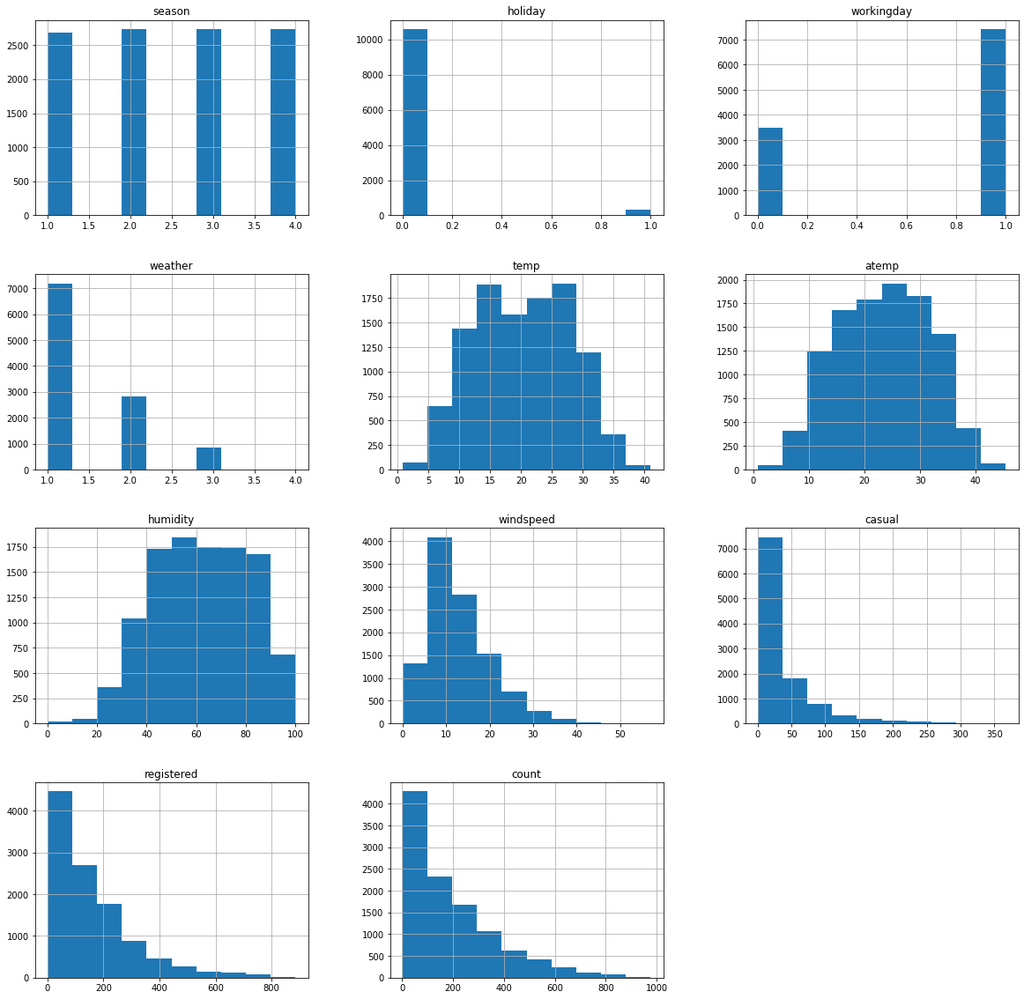

```python
train.hist(figsize=(20,20))
```

```python
train.info()
```

```
<class 'pandas.core.frame.DataFrame'>
RangeIndex: 10886 entries, 0 to 10885
Data columns (total 12 columns):
 #   Column      Non-Null Count  Dtype
---  ------      --------------  -----
 0   datetime    10886 non-null  object
 1   season      10886 non-null  int64
 2   holiday     10886 non-null  int64
 3   workingday  10886 non-null  int64
 4   weather     10886 non-null  int64
 5   temp        10886 non-null  float64
 6   atemp       10886 non-null  float64
 7   humidity    10886 non-null  int64
 8   windspeed   10886 non-null  float64
 9   casual      10886 non-null  int64
 10  registered  10886 non-null  int64
 11  count       10886 non-null  int64
dtypes: float64(3), int64(8), object(1)
memory usage: 1020.7+ KB
```

```python
# Simple output of the train dataset to view some of the min/max/varition of the dataset features.
train.describe()
```

|  | season | holiday | workingday | weather | temp | atemp | humidity | windspeed | casual | registered | count |
| --- | --- | --- | --- | --- | --- | --- | --- | --- | --- | --- | --- |
| count | 10886.000000 | 10886.000000 | 10886.000000 | 10886.000000 | 10886.00000 | 10886.000000 | 10886.000000 | 10886.000000 | 10886.000000 | 10886.000000 | 10886.000000 |
| mean | 2.506614 | 0.028569 | 0.680875 | 1.418427 | 20.23086 | 23.655084 | 61.886460 | 12.799395 | 36.021955 | 155.552177 | 191.574132 |
| std | 1.116174 | 0.166599 | 0.466159 | 0.633839 | 7.79159 | 8.474601 | 19.245033 | 8.164537 | 49.960477 | 151.039033 | 181.144454 |
| min | 1.000000 | 0.000000 | 0.000000 | 1.000000 | 0.82000 | 0.760000 | 0.000000 | 0.000000 | 0.000000 | 0.000000 | 1.000000 |
| 25% | 2.000000 | 0.000000 | 0.000000 | 1.000000 | 13.94000 | 16.665000 | 47.000000 | 7.001500 | 4.000000 | 36.000000 | 42.000000 |
| 50% | 3.000000 | 0.000000 | 1.000000 | 1.000000 | 20.50000 | 24.240000 | 62.000000 | 12.998000 | 17.000000 | 118.000000 | 145.000000 |
| 75% | 4.000000 | 0.000000 | 1.000000 | 2.000000 | 26.24000 | 31.060000 | 77.000000 | 16.997900 | 49.000000 | 222.000000 | 284.000000 |
| max | 4.000000 | 1.000000 | 1.000000 | 4.000000 | 41.00000 | 45.455000 | 100.000000 | 56.996900 | 367.000000 | 886.000000 | 977.000000 |

```python
# Create the test pandas dataframe in pandas by reading the csv, remember to parse the datetime!
test = pd.read_csv("test.csv")
test.head()
```

[output not shown]

```
array([[<AxesSubplot:title={'center':'season'}>,
        <AxesSubplot:title={'center':'holiday'}>,
        <AxesSubplot:title={'center':'workingday'}>],
       [<AxesSubplot:title={'center':'weather'}>,
        <AxesSubplot:title={'center':'temp'}>,
        <AxesSubplot:title={'center':'atemp'}>],
       [<AxesSubplot:title={'center':'humidity'}>,
        <AxesSubplot:title={'center':'windspeed'}>, <AxesSubplot:>]],
      dtype=object)
```

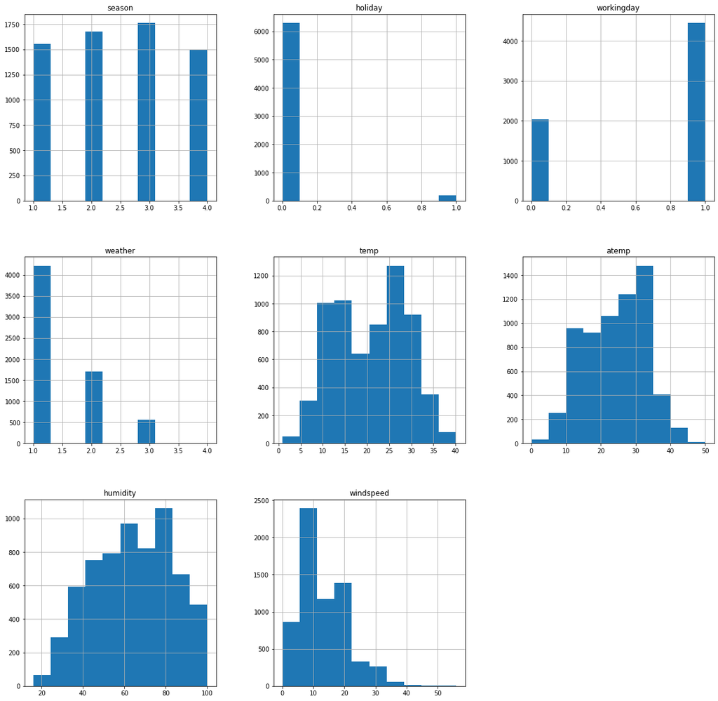

```python
#
test.hist(figsize=(20,20))
```

```python
# Same thing as train and test dataset
submission = pd.read_csv("sampleSubmission.csv")
submission.head()
```

|  | datetime | count |
| --- | --- | --- |
| 0 | 2011-01-20 00:00:00 | 0 |
| 1 | 2011-01-20 01:00:00 | 0 |
| 2 | 2011-01-20 02:00:00 | 0 |
| 3 | 2011-01-20 03:00:00 | 0 |
| 4 | 2011-01-20 04:00:00 | 0 |

## Step 3: Train a model using AutoGluon’s Tabular Prediction

Requirements:

- We are prediting `count`, so it is the label we are setting.
- Ignore `casual` and `registered` columns as they are also not present in the test dataset.
- Use the `root_mean_squared_error` as the metric to use for evaluation.
- Set a time limit of 10 minutes (600 seconds).
- Use the preset `best_quality` to focus on creating the best model.

```python
train.drop(train[["casual", "registered"]], axis=1, inplace=True)
train.head(2)
```

[output not shown]

```python
test.head(2)
```

[output not shown]

```python
predictor = TabularPredictor(
    label = 'count',
    problem_type = "regression",
    eval_metric = "root_mean_squared_error").fit(
    train_data = train,
    time_limit = 600,
    presets = "best_quality",
    )
```

```
No path specified. Models will be saved in: "AutogluonModels/ag-20211118_105609/"
Presets specified: ['best_quality']
Beginning AutoGluon training ... Time limit = 600s
AutoGluon will save models to "AutogluonModels/ag-20211118_105609/"
AutoGluon Version:  0.3.1
Train Data Rows:    10886
Train Data Columns: 9
Preprocessing data ...
Using Feature Generators to preprocess the data ...
Fitting AutoMLPipelineFeatureGenerator...
	Available Memory:                    3050.64 MB
	Train Data (Original)  Memory Usage: 1.52 MB (0.0% of available memory)
	Inferring data type of each feature based on column values. Set feature_metadata_in to manually specify special dtypes of the features.
	Stage 1 Generators:
		Fitting AsTypeFeatureGenerator...
			Note: Converting 2 features to boolean dtype as they only contain 2 unique values.
	Stage 2 Generators:
		Fitting FillNaFeatureGenerator...
	Stage 3 Generators:
		Fitting IdentityFeatureGenerator...
		Fitting DatetimeFeatureGenerator...
	Stage 4 Generators:
		Fitting DropUniqueFeatureGenerator...
	Types of features in original data (raw dtype, special dtypes):
		('float', [])                      : 3 | ['temp', 'atemp', 'windspeed']
		('int', [])                        : 5 | ['season', 'holiday', 'workingday', 'weather', 'humidity']
		('object', ['datetime_as_object']) : 1 | ['datetime']
	Types of features in processed data (raw dtype, special dtypes):
		('float', [])                : 3 | ['temp', 'atemp', 'windspeed']
		('int', [])                  : 3 | ['season', 'weather', 'humidity']
		('int', ['bool'])            : 2 | ['holiday', 'workingday']
		('int', ['datetime_as_int']) : 1 | ['datetime']
	0.2s = Fit runtime
	9 features in original data used to generate 9 features in processed data.
	Train Data (Processed) Memory Usage: 0.63 MB (0.0% of available memory)
Data preprocessing and feature engineering runtime = 0.25s ...
AutoGluon will gauge predictive performance using evaluation metric: 'root_mean_squared_error'
	To change this, specify the eval_metric argument of fit()
AutoGluon will fit 2 stack levels (L1 to L2) ...
Fitting 11 L1 models ...
Fitting model: KNeighborsUnif_BAG_L1 ... Training model for up to 399.73s of the 599.74s of remaining time.
	-160.4131	 = Validation score   (root_mean_squared_error)
	0.04s	 = Training   runtime
	0.1s	 = Validation runtime
Fitting model: KNeighborsDist_BAG_L1 ... Training model for up to 399.32s of the 599.33s of remaining time.
	-169.5521	 = Validation score   (root_mean_squared_error)
	0.02s	 = Training   runtime
	0.1s	 = Validation runtime
Fitting model: LightGBMXT_BAG_L1 ... Training model for up to 398.94s of the 598.95s of remaining time.
```

```
[1000]	train_set's rmse: 123.806	valid_set's rmse: 134.369
[2000]	train_set's rmse: 117.412	valid_set's rmse: 133.705
```

```
[1000]	train_set's rmse: 123.42	valid_set's rmse: 141.5
```

```
[1000]	train_set's rmse: 125.097	valid_set's rmse: 128.797
[2000]	train_set's rmse: 119.003	valid_set's rmse: 127.909
[3000]	train_set's rmse: 114.63	valid_set's rmse: 127.431
[4000]	train_set's rmse: 111.295	valid_set's rmse: 126.943
[5000]	train_set's rmse: 108.576	valid_set's rmse: 126.844
[6000]	train_set's rmse: 106.085	valid_set's rmse: 126.71
```

```
[1000]	train_set's rmse: 124.131	valid_set's rmse: 138.303
[2000]	train_set's rmse: 117.833	valid_set's rmse: 137.535
```

```
[1000]	train_set's rmse: 124.871	valid_set's rmse: 128.052
[2000]	train_set's rmse: 118.547	valid_set's rmse: 127.003
[3000]	train_set's rmse: 114.124	valid_set's rmse: 126.834
[4000]	train_set's rmse: 110.645	valid_set's rmse: 126.694
```

```
[1000]	train_set's rmse: 124.654	valid_set's rmse: 135.095
[2000]	train_set's rmse: 118.764	valid_set's rmse: 133.849
[3000]	train_set's rmse: 114.615	valid_set's rmse: 133.509
[4000]	train_set's rmse: 111.249	valid_set's rmse: 133.472
[5000]	train_set's rmse: 108.455	valid_set's rmse: 133.281
```

```
[1000]	train_set's rmse: 124.01	valid_set's rmse: 139.355
[2000]	train_set's rmse: 117.819	valid_set's rmse: 138.312
[3000]	train_set's rmse: 113.4	valid_set's rmse: 137.886
[4000]	train_set's rmse: 110.032	valid_set's rmse: 137.758
```

```
[1000]	train_set's rmse: 124.47	valid_set's rmse: 135.412
```

```
[1000]	train_set's rmse: 124.18	valid_set's rmse: 137.579
[2000]	train_set's rmse: 117.782	valid_set's rmse: 136.664
[3000]	train_set's rmse: 113.447	valid_set's rmse: 136.246
[4000]	train_set's rmse: 109.982	valid_set's rmse: 136.227
```

```
[1000]	train_set's rmse: 124.641	valid_set's rmse: 132.484
```

```
	-134.0883	 = Validation score   (root_mean_squared_error)
	44.61s	 = Training   runtime
	2.29s	 = Validation runtime
Fitting model: LightGBM_BAG_L1 ... Training model for up to 345.99s of the 546.0s of remaining time.
```

```
[1000]	train_set's rmse: 96.0217	valid_set's rmse: 123.249
```

```
[1000]	train_set's rmse: 94.7479	valid_set's rmse: 135.635
```

```
[1000]	train_set's rmse: 95.3055	valid_set's rmse: 132.087
```

```
[1000]	train_set's rmse: 95.1635	valid_set's rmse: 131.521
```

[output not shown]

[output cut: 81 more lines]

```
No improvement since epoch 5: early stopping
	-115.5009	 = Validation score   (root_mean_squared_error)
	99.95s	 = Training   runtime
	0.34s	 = Validation runtime
Fitting model: XGBoost_BAG_L2 ... Training model for up to 12.63s of the 12.59s of remaining time.
	-117.3485	 = Validation score   (root_mean_squared_error)
	11.56s	 = Training   runtime
	0.07s	 = Validation runtime
Completed 1/20 k-fold bagging repeats ...
Fitting model: WeightedEnsemble_L3 ... Training model for up to 360.0s of the -0.12s of remaining time.
	-114.9102	 = Validation score   (root_mean_squared_error)
	0.36s	 = Training   runtime
	0.0s	 = Validation runtime
AutoGluon training complete, total runtime = 600.75s ...
TabularPredictor saved. To load, use: predictor = TabularPredictor.load("AutogluonModels/ag-20211118_105609/")
```

### Review AutoGluon's training run with ranking of models that did the best.

```python
predictor.fit_summary()
```

```
*** Summary of fit() ***
Estimated performance of each model:
                     model   score_val  pred_time_val    fit_time  pred_time_val_marginal  fit_time_marginal  stack_level  can_infer  fit_order
0      WeightedEnsemble_L3 -114.910249       6.956697  508.297941                0.000738           0.364238            3       True         19
1   NeuralNetFastAI_BAG_L2 -115.500898       6.144084  471.220652                0.340398          99.954887            2       True         17
2        LightGBMXT_BAG_L2 -116.242249       6.022020  382.774326                0.218333          11.508560            2       True         12
3          CatBoost_BAG_L2 -116.730122       5.838012  398.248648                0.034325          26.982883            2       True         15
4          LightGBM_BAG_L2 -116.892222       5.876158  378.553626                0.072472           7.287860            2       True         13
5           XGBoost_BAG_L2 -117.348547       5.874050  382.826778                0.070363          11.561013            2       True         18
6     ExtraTreesMSE_BAG_L2 -117.514582       6.254394  377.621383                0.450707           6.355617            2       True         16
7      WeightedEnsemble_L2 -118.441197       2.013538  128.462846                0.000685           0.489042            2       True         11
8   RandomForestMSE_BAG_L1 -118.456660       0.374079    6.980611                0.374079           6.980611            1       True          5
9   RandomForestMSE_BAG_L2 -119.582996       6.267824  400.356944                0.464138          29.091179            2       True         14
10    ExtraTreesMSE_BAG_L1 -128.733445       0.380531    3.032301                0.380531           3.032301            1       True          7
11         LightGBM_BAG_L1 -132.286410       0.450913   13.101878                0.450913          13.101878            1       True          4
12          XGBoost_BAG_L1 -132.308522       0.137241   14.695785                0.137241          14.695785            1       True          9
13         CatBoost_BAG_L1 -132.349692       0.045079   59.652768                0.045079          59.652768            1       True          6
14       LightGBMXT_BAG_L1 -134.088334       2.287201   44.611987                2.287201          44.611987            1       True          3
15  NeuralNetFastAI_BAG_L1 -137.981375       0.282743  108.133965                0.282743         108.133965            1       True          8
16   NeuralNetMXNet_BAG_L1 -143.437685       1.638774  120.993193                1.638774         120.993193            1       True         10
17   KNeighborsUnif_BAG_L1 -160.413078       0.103014    0.042516                0.103014           0.042516            1       True          1
18   KNeighborsDist_BAG_L1 -169.552096       0.104112    0.020762                0.104112           0.020762            1       True          2
Number of models trained: 19
Types of models trained:
{'StackerEnsembleModel_KNN', 'WeightedEnsembleModel', 'StackerEnsembleModel_LGB', 'StackerEnsembleModel_XGBoost', 'StackerEnsembleModel_RF', 'StackerEnsembleModel_XT', 'StackerEnsembleModel_TabularNeuralNet', 'StackerEnsembleModel_NNFastAiTabular', 'StackerEnsembleModel_CatBoost'}
Bagging used: True  (with 10 folds)
Multi-layer stack-ensembling used: True  (with 3 levels)
Feature Metadata (Processed):
(raw dtype, special dtypes):
('float', [])                : 3 | ['temp', 'atemp', 'windspeed']
('int', [])                  : 3 | ['season', 'weather', 'humidity']
('int', ['bool'])            : 2 | ['holiday', 'workingday']
('int', ['datetime_as_int']) : 1 | ['datetime']
Plot summary of models saved to file: AutogluonModels/ag-20211118_105609/SummaryOfModels.html
*** End of fit() summary ***
```

```
{'model_types': {'KNeighborsUnif_BAG_L1': 'StackerEnsembleModel_KNN',
  'KNeighborsDist_BAG_L1': 'StackerEnsembleModel_KNN',
  'LightGBMXT_BAG_L1': 'StackerEnsembleModel_LGB',
  'LightGBM_BAG_L1': 'StackerEnsembleModel_LGB',
  'RandomForestMSE_BAG_L1': 'StackerEnsembleModel_RF',
  'CatBoost_BAG_L1': 'StackerEnsembleModel_CatBoost',
  'ExtraTreesMSE_BAG_L1': 'StackerEnsembleModel_XT',
  'NeuralNetFastAI_BAG_L1': 'StackerEnsembleModel_NNFastAiTabular',
  'XGBoost_BAG_L1': 'StackerEnsembleModel_XGBoost',
  'NeuralNetMXNet_BAG_L1': 'StackerEnsembleModel_TabularNeuralNet',
  'WeightedEnsemble_L2': 'WeightedEnsembleModel',
  'LightGBMXT_BAG_L2': 'StackerEnsembleModel_LGB',
  'LightGBM_BAG_L2': 'StackerEnsembleModel_LGB',
  'RandomForestMSE_BAG_L2': 'StackerEnsembleModel_RF',
  'CatBoost_BAG_L2': 'StackerEnsembleModel_CatBoost',
  'ExtraTreesMSE_BAG_L2': 'StackerEnsembleModel_XT',
  'NeuralNetFastAI_BAG_L2': 'StackerEnsembleModel_NNFastAiTabular',
  'XGBoost_BAG_L2': 'StackerEnsembleModel_XGBoost',
  'WeightedEnsemble_L3': 'WeightedEnsembleModel'},
 'model_performance': {'KNeighborsUnif_BAG_L1': -160.4130779463501,
  'KNeighborsDist_BAG_L1': -169.55209635208928,
  'LightGBMXT_BAG_L1': -134.08833420116997,
  'LightGBM_BAG_L1': -132.28640961443517,
  'RandomForestMSE_BAG_L1': -118.45666016795705,
  'CatBoost_BAG_L1': -132.34969157134555,
  'ExtraTreesMSE_BAG_L1': -128.7334450621692,
  'NeuralNetFastAI_BAG_L1': -137.98137535248551,
  'XGBoost_BAG_L1': -132.30852184526813,
  'NeuralNetMXNet_BAG_L1': -143.4376851918966,
  'WeightedEnsemble_L2': -118.44119659833629,
  'LightGBMXT_BAG_L2': -116.24224890205865,
  'LightGBM_BAG_L2': -116.8922221458803,
  'RandomForestMSE_BAG_L2': -119.58299583025475,
  'CatBoost_BAG_L2': -116.73012245059802,
  'ExtraTreesMSE_BAG_L2': -117.51458232635912,
  'NeuralNetFastAI_BAG_L2': -115.50089798853796,
  'XGBoost_BAG_L2': -117.34854652389555,
  'WeightedEnsemble_L3': -114.9102492495795},
 'model_best': 'WeightedEnsemble_L3',
 'model_paths': {'KNeighborsUnif_BAG_L1': 'AutogluonModels/ag-20211118_105609/models/KNeighborsUnif_BAG_L1/',
```

[output cut: 187 more lines]

```
 4          13
 5          18
 6          16
 7          11
 8           5
 9          14
 10          7
 11          4
 12          9
 13          6
 14          3
 15          8
 16         10
 17          1
 18          2  }
```

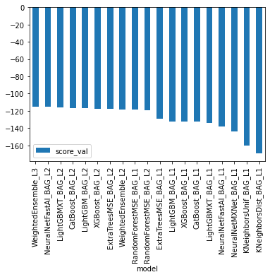

```python
predictor.leaderboard(silent=True).plot(kind="bar", x="model", y="score_val")
```

### Create predictions from test dataset

```python
predictions = predictor.predict_proba(test)
predictions.head()
```

```
0     98.064911
1     93.315666
2     93.316490
3    106.919289
4    106.877464
Name: count, dtype: float32
```

#### NOTE: Kaggle will reject the submission if we don't set everything to be > 0.

```python
submission = pd.DataFrame({'datetime': test['datetime'],
                           'count': predictions})
```

```python
# Describe the `predictions` series to see if there are any negative values
submission.describe()
```

|  | count |
| --- | --- |
| count | 6493.000000 |
| mean | 210.534805 |
| std | 128.568588 |
| min | -6.650025 |
| 25% | 106.036339 |
| 50% | 192.866669 |
| 75% | 298.024048 |
| max | 653.251709 |

```python
# How many negative values do we have?
(predictions < 0).value_counts()
```

```
False    6491
True        2
Name: count, dtype: int64
```

```python
# Set them to zero
def set_neg_to_zero(predictions):
    temp = []
    for i in range(len(predictions)):
        if predictions[i] < 0 :
            predictions[i] = 0
    return predictions

predictions = set_neg_to_zero(predictions)
```

### Set predictions to submission dataframe, save, and submit

```python
submission.to_csv("submission.csv", index=False)
```

```python
!kaggle competitions submit -c bike-sharing-demand -f submission.csv -m "first raw submission"
```

```
Successfully submitted to Bike Sharing Demand
```

#### View submission via the command line or in the web browser under the competition's page - `My Submissions`

```python
!kaggle competitions submissions -c bike-sharing-demand | tail -n +1 | head -n 6
```

```
fileName                     date                 description                        status    publicScore  privateScore
---------------------------  -------------------  ---------------------------------  --------  -----------  ------------
submission.csv               2021-11-18 11:10:47  first raw submission               complete  1.39090      1.39090
submission.csv               2021-11-15 09:43:10  first raw submission               complete  1.38750      1.38750
submission_new_hpo.csv       2021-11-15 09:29:48  new features with hyperparameters  complete  0.45873      0.45873
submission_new_features.csv  2021-11-15 09:18:21  new features                       complete  0.45737      0.45737
```

## Step 4: Exploratory Data Analysis and Creating an additional feature

- Any additional feature will do, but a great suggestion would be to separate out the datetime into hour, day, or month parts.

```python
# Checking datatypes

print("Train Data types: \n{}".format(train.dtypes))
print("\nTest Data types: \n{}".format(test.dtypes))
```

```
Train Data types:
datetime       object
season          int64
holiday         int64
workingday      int64
weather         int64
temp          float64
atemp         float64
humidity        int64
windspeed     float64
count           int64
dtype: object

Test Data types:
datetime       object
season          int64
holiday         int64
workingday      int64
weather         int64
temp          float64
atemp         float64
humidity        int64
windspeed     float64
dtype: object
```

```python
train['datetime'] = pd.to_datetime(train['datetime'], format='%Y-%m-%d %H:%M:%S')
test['datetime'] = pd.to_datetime(test['datetime'], format='%Y-%m-%d %H:%M:%S')
```

```python
train['year'] = train['datetime'].dt.year
train['month'] = train['datetime'].dt.month
train['day'] = train['datetime'].dt.day
train['hour'] =train['datetime'].dt.hour
train.isnull().values.any()
```

```
False
```

```
array([[<AxesSubplot:title={'center':'datetime'}>,
        <AxesSubplot:title={'center':'season'}>,
        <AxesSubplot:title={'center':'holiday'}>,
        <AxesSubplot:title={'center':'workingday'}>],
       [<AxesSubplot:title={'center':'weather'}>,
        <AxesSubplot:title={'center':'temp'}>,
        <AxesSubplot:title={'center':'atemp'}>,
        <AxesSubplot:title={'center':'humidity'}>],
       [<AxesSubplot:title={'center':'windspeed'}>,
        <AxesSubplot:title={'center':'count'}>,
        <AxesSubplot:title={'center':'year'}>,
        <AxesSubplot:title={'center':'month'}>],
       [<AxesSubplot:title={'center':'day'}>,
        <AxesSubplot:title={'center':'hour'}>, <AxesSubplot:>,
        <AxesSubplot:>]], dtype=object)
```

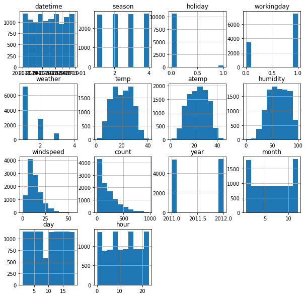

```python
# Create a histogram of all features to show the distribution of each one relative to the data. This is part of the exploritory data analysis
train.hist(bins=10, figsize=[10,10])
```

```python
# create a new feature
test['year'] = test['datetime'].dt.year
test['month'] = test['datetime'].dt.month
test['day'] = test['datetime'].dt.day
test['hour'] =test['datetime'].dt.hour
```

```python
train.drop(train[['datetime']], axis=1, inplace=True)
test.drop(test[['datetime']], axis=1, inplace=True)
```

## Make category types for these so models know they are not just numbers

```python
train["season"] = train["season"].astype("category")
train["weather"] = train["weather"].astype("category")
test["season"] = test["season"].astype("category")
test["weather"] = test["weather"].astype("category")
train["holiday"] = train["holiday"].astype("category")
train["workingday"] = train["workingday"].astype("category")
test["holiday"] = test["holiday"].astype("category")
test["workingday"] = test["workingday"].astype("category")
```

```python
# View are new feature
train.info()
```

```
<class 'pandas.core.frame.DataFrame'>
RangeIndex: 10886 entries, 0 to 10885
Data columns (total 13 columns):
 #   Column      Non-Null Count  Dtype
---  ------      --------------  -----
 0   season      10886 non-null  category
 1   holiday     10886 non-null  category
 2   workingday  10886 non-null  category
 3   weather     10886 non-null  category
 4   temp        10886 non-null  float64
 5   atemp       10886 non-null  float64
 6   humidity    10886 non-null  int64
 7   windspeed   10886 non-null  float64
 8   count       10886 non-null  int64
 9   year        10886 non-null  int64
 10  month       10886 non-null  int64
 11  day         10886 non-null  int64
 12  hour        10886 non-null  int64
dtypes: category(4), float64(3), int64(6)
memory usage: 808.7 KB
```

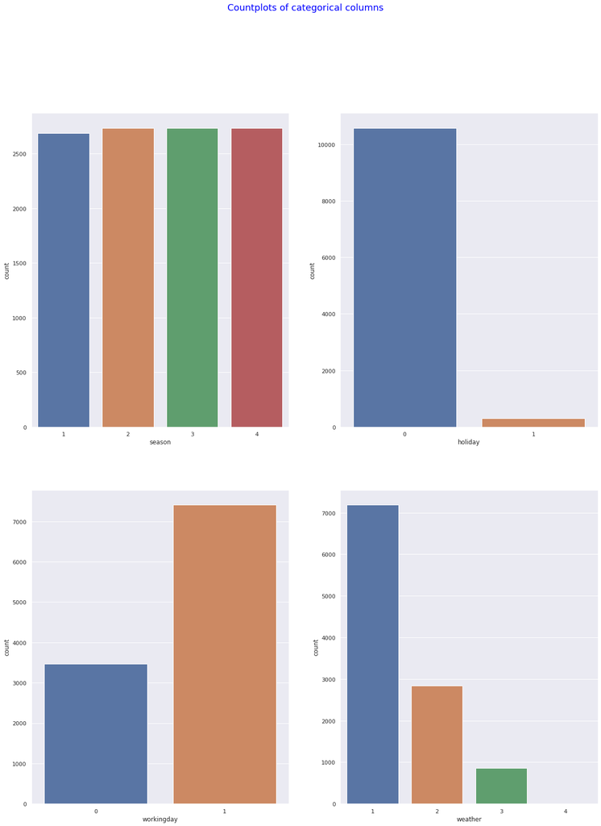

```python
# Count plot of categorical columns in the dataset
import seaborn as sns

cat_cols = train.iloc[: , :4]

sns.set(style = 'darkgrid', context = 'notebook')
fig, axes = plt.subplots(nrows=2, ncols=2, figsize=(20,25))
plt.suptitle('Countplots of categorical columns', fontsize = 18, y = 1, color = 'blue')
for ax, data, column in zip(axes.flatten(), train, cat_cols):
   sns.countplot(train[column], ax=ax)
```

```python
train.weather.value_counts()
```

```
1    7192
2    2834
3     859
4       1
Name: weather, dtype: int64
```

```python
train.holiday.value_counts()
```

```
0    10575
1      311
Name: holiday, dtype: int64
```

## Step 5: Rerun the model with the same settings as before, just with more features

```python
predictor_new_features = TabularPredictor(
    label = 'count',
    problem_type = "regression",
    eval_metric = "root_mean_squared_error").fit(
    train_data = train,
    time_limit = 600,
    presets = "best_quality",
    )
```

```
No path specified. Models will be saved in: "AutogluonModels/ag-20211118_111330/"
Presets specified: ['best_quality']
Beginning AutoGluon training ... Time limit = 600s
AutoGluon will save models to "AutogluonModels/ag-20211118_111330/"
AutoGluon Version:  0.3.1
Train Data Rows:    10886
Train Data Columns: 12
Preprocessing data ...
Using Feature Generators to preprocess the data ...
Fitting AutoMLPipelineFeatureGenerator...
	Available Memory:                    1980.66 MB
	Train Data (Original)  Memory Usage: 0.74 MB (0.0% of available memory)
	Inferring data type of each feature based on column values. Set feature_metadata_in to manually specify special dtypes of the features.
	Stage 1 Generators:
		Fitting AsTypeFeatureGenerator...
			Note: Converting 3 features to boolean dtype as they only contain 2 unique values.
	Stage 2 Generators:
		Fitting FillNaFeatureGenerator...
	Stage 3 Generators:
		Fitting IdentityFeatureGenerator...
		Fitting CategoryFeatureGenerator...
			Fitting CategoryMemoryMinimizeFeatureGenerator...
	Stage 4 Generators:
		Fitting DropUniqueFeatureGenerator...
	Types of features in original data (raw dtype, special dtypes):
		('category', []) : 4 | ['season', 'holiday', 'workingday', 'weather']
		('float', [])    : 3 | ['temp', 'atemp', 'windspeed']
		('int', [])      : 5 | ['humidity', 'year', 'month', 'day', 'hour']
	Types of features in processed data (raw dtype, special dtypes):
		('category', [])  : 2 | ['season', 'weather']
		('float', [])     : 3 | ['temp', 'atemp', 'windspeed']
		('int', [])       : 4 | ['humidity', 'month', 'day', 'hour']
		('int', ['bool']) : 3 | ['holiday', 'workingday', 'year']
	0.2s = Fit runtime
	12 features in original data used to generate 12 features in processed data.
	Train Data (Processed) Memory Usage: 0.67 MB (0.0% of available memory)
Data preprocessing and feature engineering runtime = 0.26s ...
AutoGluon will gauge predictive performance using evaluation metric: 'root_mean_squared_error'
	To change this, specify the eval_metric argument of fit()
AutoGluon will fit 2 stack levels (L1 to L2) ...
Fitting 11 L1 models ...
Fitting model: KNeighborsUnif_BAG_L1 ... Training model for up to 399.73s of the 599.74s of remaining time.
	-123.9216	 = Validation score   (root_mean_squared_error)
	0.05s	 = Training   runtime
	0.2s	 = Validation runtime
Fitting model: KNeighborsDist_BAG_L1 ... Training model for up to 399.19s of the 599.2s of remaining time.
	-119.3726	 = Validation score   (root_mean_squared_error)
	0.02s	 = Training   runtime
	0.2s	 = Validation runtime
Fitting model: LightGBMXT_BAG_L1 ... Training model for up to 398.69s of the 598.7s of remaining time.
```

```
[1000]	train_set's rmse: 30.8448	valid_set's rmse: 37.6336
[2000]	train_set's rmse: 25.828	valid_set's rmse: 36.1946
[3000]	train_set's rmse: 23.051	valid_set's rmse: 35.8247
[4000]	train_set's rmse: 21.035	valid_set's rmse: 35.7445
[5000]	train_set's rmse: 19.5137	valid_set's rmse: 35.7086
[6000]	train_set's rmse: 18.2362	valid_set's rmse: 35.8171
```

```
[1000]	train_set's rmse: 30.5612	valid_set's rmse: 41.6676
[2000]	train_set's rmse: 25.8336	valid_set's rmse: 39.54
[3000]	train_set's rmse: 23.117	valid_set's rmse: 38.8123
[4000]	train_set's rmse: 21.1553	valid_set's rmse: 38.4164
[5000]	train_set's rmse: 19.6323	valid_set's rmse: 38.1866
[6000]	train_set's rmse: 18.3473	valid_set's rmse: 38.0474
[7000]	train_set's rmse: 17.2846	valid_set's rmse: 37.9464
[8000]	train_set's rmse: 16.372	valid_set's rmse: 37.94
```

```
[1000]	train_set's rmse: 31.3639	valid_set's rmse: 35.7492
[2000]	train_set's rmse: 26.0704	valid_set's rmse: 34.4707
[3000]	train_set's rmse: 23.2701	valid_set's rmse: 34.2788
```

```
[1000]	train_set's rmse: 30.4546	valid_set's rmse: 41.3533
[2000]	train_set's rmse: 25.6382	valid_set's rmse: 39.8927
[3000]	train_set's rmse: 22.9751	valid_set's rmse: 39.2533
[4000]	train_set's rmse: 21.0503	valid_set's rmse: 38.8709
[5000]	train_set's rmse: 19.5613	valid_set's rmse: 38.5367
[6000]	train_set's rmse: 18.3487	valid_set's rmse: 38.305
[7000]	train_set's rmse: 17.2815	valid_set's rmse: 38.2156
[8000]	train_set's rmse: 16.3686	valid_set's rmse: 38.1137
[9000]	train_set's rmse: 15.5887	valid_set's rmse: 38.0142
[10000]	train_set's rmse: 14.8791	valid_set's rmse: 37.9498
```

```
[1000]	train_set's rmse: 30.9875	valid_set's rmse: 38.3401
[2000]	train_set's rmse: 25.7763	valid_set's rmse: 37.0177
[3000]	train_set's rmse: 23.002	valid_set's rmse: 36.7936
```

```
[1000]	train_set's rmse: 30.4742	valid_set's rmse: 41.682
[2000]	train_set's rmse: 25.6489	valid_set's rmse: 40.6328
[3000]	train_set's rmse: 22.8889	valid_set's rmse: 40.5213
```

```
[1000]	train_set's rmse: 31.098	valid_set's rmse: 38.972
[2000]	train_set's rmse: 26.1518	valid_set's rmse: 36.3259
[3000]	train_set's rmse: 23.3675	valid_set's rmse: 35.4266
[4000]	train_set's rmse: 21.3853	valid_set's rmse: 35.0473
[5000]	train_set's rmse: 19.8391	valid_set's rmse: 34.757
[6000]	train_set's rmse: 18.5142	valid_set's rmse: 34.7085
[7000]	train_set's rmse: 17.4016	valid_set's rmse: 34.6766
[8000]	train_set's rmse: 16.4616	valid_set's rmse: 34.6475
[9000]	train_set's rmse: 15.6291	valid_set's rmse: 34.7439
```

```
[1000]	train_set's rmse: 30.8466	valid_set's rmse: 39.2976
[2000]	train_set's rmse: 26.0207	valid_set's rmse: 37.8817
[3000]	train_set's rmse: 23.2835	valid_set's rmse: 37.4878
[4000]	train_set's rmse: 21.3296	valid_set's rmse: 37.2575
[5000]	train_set's rmse: 19.8148	valid_set's rmse: 37.1754
[6000]	train_set's rmse: 18.5534	valid_set's rmse: 37.1665
[7000]	train_set's rmse: 17.4554	valid_set's rmse: 37.1512
```

```
[1000]	train_set's rmse: 30.5918	valid_set's rmse: 40.7142
[2000]	train_set's rmse: 25.67	valid_set's rmse: 39.7503
[3000]	train_set's rmse: 22.9445	valid_set's rmse: 39.4996
[4000]	train_set's rmse: 20.9835	valid_set's rmse: 39.3705
```

```
[1000]	train_set's rmse: 31.1017	valid_set's rmse: 37.2527
[2000]	train_set's rmse: 26.25	valid_set's rmse: 35.3479
[3000]	train_set's rmse: 23.4971	valid_set's rmse: 34.9821
[4000]	train_set's rmse: 21.5279	valid_set's rmse: 34.7372
[5000]	train_set's rmse: 20.0153	valid_set's rmse: 34.5702
[6000]	train_set's rmse: 18.7423	valid_set's rmse: 34.4775
[7000]	train_set's rmse: 17.6617	valid_set's rmse: 34.4356
[8000]	train_set's rmse: 16.7156	valid_set's rmse: 34.4889
```

```
	-36.9063	 = Validation score   (root_mean_squared_error)
	89.39s	 = Training   runtime
	4.94s	 = Validation runtime
Fitting model: LightGBM_BAG_L1 ... Training model for up to 293.26s of the 493.27s of remaining time.
```

```
[1000]	train_set's rmse: 22.1618	valid_set's rmse: 37.7812
```

```
[1000]	train_set's rmse: 22.2426	valid_set's rmse: 38.6453
[2000]	train_set's rmse: 16.4312	valid_set's rmse: 37.5551
[3000]	train_set's rmse: 12.8832	valid_set's rmse: 37.2872
```

```
[1000]	train_set's rmse: 22.3749	valid_set's rmse: 33.6347
```

```
[1000]	train_set's rmse: 21.8266	valid_set's rmse: 39.0645
[2000]	train_set's rmse: 16.2789	valid_set's rmse: 38.6651
[3000]	train_set's rmse: 12.8405	valid_set's rmse: 38.421
```

```
[1000]	train_set's rmse: 21.9076	valid_set's rmse: 38.1606
[2000]	train_set's rmse: 15.9937	valid_set's rmse: 37.7241
```

```
[1000]	train_set's rmse: 22.0474	valid_set's rmse: 40.9269
[2000]	train_set's rmse: 16.2441	valid_set's rmse: 40.1943
[3000]	train_set's rmse: 12.8116	valid_set's rmse: 40.0522
```

```
[1000]	train_set's rmse: 22.1679	valid_set's rmse: 36.2386
[2000]	train_set's rmse: 16.0504	valid_set's rmse: 35.5971
```

```
[1000]	train_set's rmse: 21.9424	valid_set's rmse: 37.3976
```

```
[1000]	train_set's rmse: 22.4023	valid_set's rmse: 41.5862
[2000]	train_set's rmse: 16.4244	valid_set's rmse: 41.1072
```

```
[1000]	train_set's rmse: 22.7887	valid_set's rmse: 37.2757
```

```
	-37.5491	 = Validation score   (root_mean_squared_error)
	32.13s	 = Training   runtime
	1.33s	 = Validation runtime
Fitting model: RandomForestMSE_BAG_L1 ... Training model for up to 255.6s of the 455.61s of remaining time.
	-42.1946	 = Validation score   (root_mean_squared_error)
	8.16s	 = Training   runtime
	0.45s	 = Validation runtime
Fitting model: CatBoost_BAG_L1 ... Training model for up to 244.44s of the 444.44s of remaining time.
	Time limit exceeded... Skipping CatBoost_BAG_L1.
Fitting model: ExtraTreesMSE_BAG_L1 ... Training model for up to 215.92s of the 415.92s of remaining time.
	-41.6115	 = Validation score   (root_mean_squared_error)
	3.64s	 = Training   runtime
	0.4s	 = Validation runtime
Fitting model: NeuralNetFastAI_BAG_L1 ... Training model for up to 209.46s of the 409.47s of remaining time.
	-46.4765	 = Validation score   (root_mean_squared_error)
	133.75s	 = Training   runtime
	0.35s	 = Validation runtime
Fitting model: XGBoost_BAG_L1 ... Training model for up to 74.5s of the 274.51s of remaining time.
	-39.0042	 = Validation score   (root_mean_squared_error)
	23.2s	 = Training   runtime
	0.28s	 = Validation runtime
Fitting model: NeuralNetMXNet_BAG_L1 ... Training model for up to 48.07s of the 248.08s of remaining time.
	Ran out of time, stopping training early. (Stopping on epoch 2)
	Ran out of time, stopping training early. (Stopping on epoch 2)
	Ran out of time, stopping training early. (Stopping on epoch 2)
	Ran out of time, stopping training early. (Stopping on epoch 2)
	Ran out of time, stopping training early. (Stopping on epoch 2)
	Ran out of time, stopping training early. (Stopping on epoch 3)
	Ran out of time, stopping training early. (Stopping on epoch 3)
	Ran out of time, stopping training early. (Stopping on epoch 3)
	Ran out of time, stopping training early. (Stopping on epoch 4)
	Ran out of time, stopping training early. (Stopping on epoch 4)
	-205.26	 = Validation score   (root_mean_squared_error)
	43.27s	 = Training   runtime
	2.4s	 = Validation runtime
Fitting model: LightGBMLarge_BAG_L1 ... Training model for up to 1.79s of the 201.8s of remaining time.
	Ran out of time, early stopping on iteration 1. Best iteration is:
	[1]	train_set's rmse: 176.361	valid_set's rmse: 174.681
	Time limit exceeded... Skipping LightGBMLarge_BAG_L1.
Completed 1/20 k-fold bagging repeats ...
```

[output cut: 39 more lines]

```
Fitting model: XGBoost_BAG_L2 ... Training model for up to 3.41s of the 3.37s of remaining time.
	Time limit exceeded... Skipping XGBoost_BAG_L2.
Fitting model: NeuralNetMXNet_BAG_L2 ... Training model for up to 2.97s of the 2.94s of remaining time.
	Time limit exceeded... Skipping NeuralNetMXNet_BAG_L2.
Fitting model: LightGBMLarge_BAG_L2 ... Training model for up to 2.26s of the 2.22s of remaining time.
	Ran out of time, early stopping on iteration 1. Best iteration is:
	[1]	train_set's rmse: 176.205	valid_set's rmse: 172.848
	Time limit exceeded... Skipping LightGBMLarge_BAG_L2.
Completed 1/20 k-fold bagging repeats ...
Fitting model: WeightedEnsemble_L3 ... Training model for up to 360.0s of the 1.86s of remaining time.
	-35.6709	 = Validation score   (root_mean_squared_error)
	0.31s	 = Training   runtime
	0.0s	 = Validation runtime
AutoGluon training complete, total runtime = 598.71s ...
TabularPredictor saved. To load, use: predictor = TabularPredictor.load("AutogluonModels/ag-20211118_111330/")
```

```python
predictor_new_features.fit_summary()
```

```
*** Summary of fit() ***
Estimated performance of each model:
                     model   score_val  pred_time_val    fit_time  pred_time_val_marginal  fit_time_marginal  stack_level  can_infer  fit_order
0      WeightedEnsemble_L3  -35.670901      12.048952  513.758588                0.000762           0.311283            3       True         17
1      WeightedEnsemble_L2  -35.858198       7.354361  287.091582                0.000676           0.457771            2       True         10
2     ExtraTreesMSE_BAG_L2  -36.065972      11.019421  340.462451                0.459835           6.849425            2       True         15
3          CatBoost_BAG_L2  -36.124998      10.627854  377.053409                0.068268          43.440383            2       True         14
4          LightGBM_BAG_L2  -36.236552      10.653426  340.787828                0.093840           7.174801            2       True         12
5   NeuralNetFastAI_BAG_L2  -36.470646      10.954231  429.796941                0.394645          96.183915            2       True         16
6   RandomForestMSE_BAG_L2  -36.672002      11.031601  359.798782                0.472015          26.185755            2       True         13
7        LightGBMXT_BAG_L2  -36.680349      10.723310  342.424560                0.163724           8.811533            2       True         11
8        LightGBMXT_BAG_L1  -36.906275       4.941710   89.389838                4.941710          89.389838            1       True          3
9          LightGBM_BAG_L1  -37.549108       1.332602   32.131469                1.332602          32.131469            1       True          4
10          XGBoost_BAG_L1  -39.004179       0.279669   23.200848                0.279669          23.200848            1       True          8
11    ExtraTreesMSE_BAG_L1  -41.611451       0.398656    3.638088                0.398656           3.638088            1       True          6
12  RandomForestMSE_BAG_L1  -42.194610       0.445346    8.158344                0.445346           8.158344            1       True          5
13  NeuralNetFastAI_BAG_L1  -46.476510       0.354358  133.753313                0.354358         133.753313            1       True          7
14   KNeighborsDist_BAG_L1 -119.372602       0.203934    0.022784                0.203934           0.022784            1       True          2
15   KNeighborsUnif_BAG_L1 -123.921631       0.204386    0.045951                0.204386           0.045951            1       True          1
16   NeuralNetMXNet_BAG_L1 -205.260047       2.398925   43.272392                2.398925          43.272392            1       True          9
Number of models trained: 17
Types of models trained:
{'StackerEnsembleModel_KNN', 'WeightedEnsembleModel', 'StackerEnsembleModel_LGB', 'StackerEnsembleModel_XGBoost', 'StackerEnsembleModel_RF', 'StackerEnsembleModel_CatBoost', 'StackerEnsembleModel_TabularNeuralNet', 'StackerEnsembleModel_NNFastAiTabular', 'StackerEnsembleModel_XT'}
Bagging used: True  (with 10 folds)
Multi-layer stack-ensembling used: True  (with 3 levels)
Feature Metadata (Processed):
(raw dtype, special dtypes):
('category', [])  : 2 | ['season', 'weather']
('float', [])     : 3 | ['temp', 'atemp', 'windspeed']
('int', [])       : 4 | ['humidity', 'month', 'day', 'hour']
('int', ['bool']) : 3 | ['holiday', 'workingday', 'year']
Plot summary of models saved to file: AutogluonModels/ag-20211118_111330/SummaryOfModels.html
*** End of fit() summary ***
```

```
{'model_types': {'KNeighborsUnif_BAG_L1': 'StackerEnsembleModel_KNN',
  'KNeighborsDist_BAG_L1': 'StackerEnsembleModel_KNN',
  'LightGBMXT_BAG_L1': 'StackerEnsembleModel_LGB',
  'LightGBM_BAG_L1': 'StackerEnsembleModel_LGB',
  'RandomForestMSE_BAG_L1': 'StackerEnsembleModel_RF',
  'ExtraTreesMSE_BAG_L1': 'StackerEnsembleModel_XT',
  'NeuralNetFastAI_BAG_L1': 'StackerEnsembleModel_NNFastAiTabular',
  'XGBoost_BAG_L1': 'StackerEnsembleModel_XGBoost',
  'NeuralNetMXNet_BAG_L1': 'StackerEnsembleModel_TabularNeuralNet',
  'WeightedEnsemble_L2': 'WeightedEnsembleModel',
  'LightGBMXT_BAG_L2': 'StackerEnsembleModel_LGB',
  'LightGBM_BAG_L2': 'StackerEnsembleModel_LGB',
  'RandomForestMSE_BAG_L2': 'StackerEnsembleModel_RF',
  'CatBoost_BAG_L2': 'StackerEnsembleModel_CatBoost',
  'ExtraTreesMSE_BAG_L2': 'StackerEnsembleModel_XT',
  'NeuralNetFastAI_BAG_L2': 'StackerEnsembleModel_NNFastAiTabular',
  'WeightedEnsemble_L3': 'WeightedEnsembleModel'},
 'model_performance': {'KNeighborsUnif_BAG_L1': -123.92163053871576,
  'KNeighborsDist_BAG_L1': -119.37260178212149,
  'LightGBMXT_BAG_L1': -36.90627469098103,
  'LightGBM_BAG_L1': -37.54910820576038,
  'RandomForestMSE_BAG_L1': -42.19461044139409,
  'ExtraTreesMSE_BAG_L1': -41.61145096445144,
  'NeuralNetFastAI_BAG_L1': -46.47650973135536,
  'XGBoost_BAG_L1': -39.004179079648836,
  'NeuralNetMXNet_BAG_L1': -205.26004671334007,
  'WeightedEnsemble_L2': -35.85819779170631,
  'LightGBMXT_BAG_L2': -36.680349174546095,
  'LightGBM_BAG_L2': -36.2365518522622,
  'RandomForestMSE_BAG_L2': -36.67200205762639,
  'CatBoost_BAG_L2': -36.12499823627693,
  'ExtraTreesMSE_BAG_L2': -36.06597226096253,
  'NeuralNetFastAI_BAG_L2': -36.4706455876194,
  'WeightedEnsemble_L3': -35.67090118414037},
 'model_best': 'WeightedEnsemble_L3',
 'model_paths': {'KNeighborsUnif_BAG_L1': 'AutogluonModels/ag-20211118_111330/models/KNeighborsUnif_BAG_L1/',
  'KNeighborsDist_BAG_L1': 'AutogluonModels/ag-20211118_111330/models/KNeighborsDist_BAG_L1/',
  'LightGBMXT_BAG_L1': 'AutogluonModels/ag-20211118_111330/models/LightGBMXT_BAG_L1/',
  'LightGBM_BAG_L1': 'AutogluonModels/ag-20211118_111330/models/LightGBM_BAG_L1/',
  'RandomForestMSE_BAG_L1': 'AutogluonModels/ag-20211118_111330/models/RandomForestMSE_BAG_L1/',
```

[output cut: 163 more lines]

```
 2          15
 3          14
 4          12
 5          16
 6          13
 7          11
 8           3
 9           4
 10          8
 11          6
 12          5
 13          7
 14          2
 15          1
 16          9  }
```

```python
predictions_new_features = predictor_new_features.predict_proba(test)
predictions_new_features.head()
```

```
0    13.513071
1     5.125259
2     3.800770
3     3.934612
4     3.762558
Name: count, dtype: float32
```

```python
# How many negative values do we have?
(predictions_new_features < 0).value_counts()
```

```
False    6493
Name: count, dtype: int64
```

```python
# Set them to zero
def set_neg_to_zero(predictions_new_features):
    temp = []
    for i in range(len(predictions_new_features)):
        if predictions_new_features[i] < 0 :
            predictions_new_features[i] = 0
    return predictions_new_features

predictions_new_features = set_neg_to_zero(predictions_new_features)
```

```python
# Remember to set all negative values to zero
submission_new_features = pd.DataFrame({'datetime': submission['datetime'],
                           'count': predictions_new_features})

submission_new_features.to_csv("submission_new_features.csv", index=False)
```

```python
!kaggle competitions submit -c bike-sharing-demand -f submission_new_features.csv -m "new features"
```

```
Successfully submitted to Bike Sharing Demand
```

```python
!kaggle competitions submissions -c bike-sharing-demand | tail -n +1 | head -n 6
```

```
fileName                     date                 description                        status    publicScore  privateScore
---------------------------  -------------------  ---------------------------------  --------  -----------  ------------
submission_new_features.csv  2021-11-18 11:24:26  new features                       complete  0.46071      0.46071
submission.csv               2021-11-18 11:10:47  first raw submission               complete  1.39090      1.39090
submission.csv               2021-11-15 09:43:10  first raw submission               complete  1.38750      1.38750
submission_new_hpo.csv       2021-11-15 09:29:48  new features with hyperparameters  complete  0.45873      0.45873
```

## Step 6: Hyper parameter optimization

- There are many options for hyper parameter optimization.
- Options are to change the AutoGluon higher level parameters or the individual model hyperparameters.
- The hyperparameters of the models themselves that are in AutoGluon. Those need the `hyperparameter` and `hyperparameter_tune_kwargs` arguments.

```python
predictor_new_hpo = TabularPredictor(
    label = 'count',
    problem_type = "regression",
    eval_metric = "root_mean_squared_error").fit(
    train_data = train,
    time_limit = 600,
    presets = "best_quality",
    hyperparameters = 'default',
    hyperparameter_tune_kwargs = 'auto',
    )
```

```
No path specified. Models will be saved in: "AutogluonModels/ag-20211118_112428/"
Presets specified: ['best_quality']
Warning: hyperparameter tuning is currently experimental and may cause the process to hang.
Beginning AutoGluon training ... Time limit = 600s
AutoGluon will save models to "AutogluonModels/ag-20211118_112428/"
AutoGluon Version:  0.3.1
Train Data Rows:    10886
Train Data Columns: 12
Preprocessing data ...
Using Feature Generators to preprocess the data ...
Fitting AutoMLPipelineFeatureGenerator...
	Available Memory:                    1933.84 MB
	Train Data (Original)  Memory Usage: 0.74 MB (0.0% of available memory)
	Inferring data type of each feature based on column values. Set feature_metadata_in to manually specify special dtypes of the features.
	Stage 1 Generators:
		Fitting AsTypeFeatureGenerator...
			Note: Converting 3 features to boolean dtype as they only contain 2 unique values.
	Stage 2 Generators:
		Fitting FillNaFeatureGenerator...
	Stage 3 Generators:
		Fitting IdentityFeatureGenerator...
		Fitting CategoryFeatureGenerator...
			Fitting CategoryMemoryMinimizeFeatureGenerator...
	Stage 4 Generators:
		Fitting DropUniqueFeatureGenerator...
	Types of features in original data (raw dtype, special dtypes):
		('category', []) : 4 | ['season', 'holiday', 'workingday', 'weather']
		('float', [])    : 3 | ['temp', 'atemp', 'windspeed']
		('int', [])      : 5 | ['humidity', 'year', 'month', 'day', 'hour']
	Types of features in processed data (raw dtype, special dtypes):
		('category', [])  : 2 | ['season', 'weather']
		('float', [])     : 3 | ['temp', 'atemp', 'windspeed']
		('int', [])       : 4 | ['humidity', 'month', 'day', 'hour']
		('int', ['bool']) : 3 | ['holiday', 'workingday', 'year']
	0.1s = Fit runtime
	12 features in original data used to generate 12 features in processed data.
	Train Data (Processed) Memory Usage: 0.67 MB (0.0% of available memory)
Data preprocessing and feature engineering runtime = 0.17s ...
AutoGluon will gauge predictive performance using evaluation metric: 'root_mean_squared_error'
	To change this, specify the eval_metric argument of fit()
AutoGluon will fit 2 stack levels (L1 to L2) ...
Fitting 11 L1 models ...
Hyperparameter tuning model: KNeighborsUnif_BAG_L1 ...
Fitted model: KNeighborsUnif_BAG_L1/T0 ...
	-123.9216	 = Validation score   (root_mean_squared_error)
	0.04s	 = Training   runtime
	0.2s	 = Validation runtime
Hyperparameter tuning model: KNeighborsDist_BAG_L1 ...
Fitted model: KNeighborsDist_BAG_L1/T0 ...
	-119.3726	 = Validation score   (root_mean_squared_error)
	0.03s	 = Training   runtime
	0.2s	 = Validation runtime
Hyperparameter tuning model: LightGBMXT_BAG_L1 ...
```

```
[1000]	train_set's rmse: 30.7673	valid_set's rmse: 38.0688
```

```
	Ran out of time, early stopping on iteration 1865. Best iteration is:
	[1859]	train_set's rmse: 26.2719	valid_set's rmse: 36.327
	Time limit exceeded
Fitted model: LightGBMXT_BAG_L1/T0 ...
	-36.327	 = Validation score   (root_mean_squared_error)
	2.88s	 = Training   runtime
	0.14s	 = Validation runtime
Hyperparameter tuning model: LightGBM_BAG_L1 ...
```

```
[1000]	train_set's rmse: 22.1618	valid_set's rmse: 37.7812
```

```
	Time limit exceeded
Fitted model: LightGBM_BAG_L1/T0 ...
	-37.7768	 = Validation score   (root_mean_squared_error)
	1.74s	 = Training   runtime
	0.07s	 = Validation runtime
Hyperparameter tuning model: RandomForestMSE_BAG_L1 ...
Fitted model: RandomForestMSE_BAG_L1/T0 ...
	-42.1946	 = Validation score   (root_mean_squared_error)
	7.85s	 = Training   runtime
	0.41s	 = Validation runtime
Hyperparameter tuning model: CatBoost_BAG_L1 ...
	Time limit exceeded
Fitted model: CatBoost_BAG_L1/T0 ...
	-40.8633	 = Validation score   (root_mean_squared_error)
	3.34s	 = Training   runtime
	0.01s	 = Validation runtime
Hyperparameter tuning model: ExtraTreesMSE_BAG_L1 ...
Fitted model: ExtraTreesMSE_BAG_L1/T0 ...
	-41.6115	 = Validation score   (root_mean_squared_error)
	3.64s	 = Training   runtime
	0.4s	 = Validation runtime
Hyperparameter tuning model: NeuralNetFastAI_BAG_L1 ...
	Ran out of time, stopping training early. (Stopping on epoch 5)
Fitted model: NeuralNetFastAI_BAG_L1/T0 ...
	-98.9507	 = Validation score   (root_mean_squared_error)
	2.6s	 = Training   runtime
	0.03s	 = Validation runtime
Hyperparameter tuning model: XGBoost_BAG_L1 ...
	Time limit exceeded
Fitted model: XGBoost_BAG_L1/T0 ...
	-37.2855	 = Validation score   (root_mean_squared_error)
	1.63s	 = Training   runtime
	0.02s	 = Validation runtime
Hyperparameter tuning model: NeuralNetMXNet_BAG_L1 ...
	Ran out of time, stopping training early. (Stopping on epoch 0)
	Time limit exceeded
Fitted model: NeuralNetMXNet_BAG_L1/T0 ...
	-292.3189	 = Validation score   (root_mean_squared_error)
	1.23s	 = Training   runtime
	0.07s	 = Validation runtime
Fitting model: LightGBMLarge_BAG_L1 ... Training model for up to 3.27s of the 554.18s of remaining time.
	Ran out of time, early stopping on iteration 808. Best iteration is:
	[808]	train_set's rmse: 11.1178	valid_set's rmse: 35.8747
	-35.8747	 = Validation score   (root_mean_squared_error)
	3.15s	 = Training   runtime
	0.08s	 = Validation runtime
Fitting model: KNeighborsUnif_BAG_L1/T0 ... Training model for up to 350.26s of the 550.29s of remaining time.
	-123.9216	 = Validation score   (root_mean_squared_error)
	0.04s	 = Training   runtime
	0.2s	 = Validation runtime
Fitting model: KNeighborsDist_BAG_L1/T0 ... Training model for up to 350.19s of the 550.22s of remaining time.
	-119.3726	 = Validation score   (root_mean_squared_error)
	0.03s	 = Training   runtime
	0.2s	 = Validation runtime
Fitting model: LightGBMXT_BAG_L1/T0 ... Training model for up to 350.1s of the 550.14s of remaining time.
```

```
[1000]	train_set's rmse: 30.5612	valid_set's rmse: 41.6676
[2000]	train_set's rmse: 25.8336	valid_set's rmse: 39.54
[3000]	train_set's rmse: 23.117	valid_set's rmse: 38.8123
[4000]	train_set's rmse: 21.1553	valid_set's rmse: 38.4164
[5000]	train_set's rmse: 19.6323	valid_set's rmse: 38.1866
[6000]	train_set's rmse: 18.3473	valid_set's rmse: 38.0474
[7000]	train_set's rmse: 17.2846	valid_set's rmse: 37.9464
[8000]	train_set's rmse: 16.372	valid_set's rmse: 37.94
```

```
[1000]	train_set's rmse: 31.3639	valid_set's rmse: 35.7492
[2000]	train_set's rmse: 26.0704	valid_set's rmse: 34.4707
[3000]	train_set's rmse: 23.2701	valid_set's rmse: 34.2788
```

```
[1000]	train_set's rmse: 30.4546	valid_set's rmse: 41.3533
[2000]	train_set's rmse: 25.6382	valid_set's rmse: 39.8927
[3000]	train_set's rmse: 22.9751	valid_set's rmse: 39.2533
[4000]	train_set's rmse: 21.0503	valid_set's rmse: 38.8709
[5000]	train_set's rmse: 19.5613	valid_set's rmse: 38.5367
[6000]	train_set's rmse: 18.3487	valid_set's rmse: 38.305
[7000]	train_set's rmse: 17.2815	valid_set's rmse: 38.2156
[8000]	train_set's rmse: 16.3686	valid_set's rmse: 38.1137
[9000]	train_set's rmse: 15.5887	valid_set's rmse: 38.0142
[10000]	train_set's rmse: 14.8791	valid_set's rmse: 37.9498
```

```
[1000]	train_set's rmse: 30.9875	valid_set's rmse: 38.3401
[2000]	train_set's rmse: 25.7763	valid_set's rmse: 37.0177
[3000]	train_set's rmse: 23.002	valid_set's rmse: 36.7936
```

```
[1000]	train_set's rmse: 30.4742	valid_set's rmse: 41.682
[2000]	train_set's rmse: 25.6489	valid_set's rmse: 40.6328
[3000]	train_set's rmse: 22.8889	valid_set's rmse: 40.5213
```

```
[1000]	train_set's rmse: 31.098	valid_set's rmse: 38.972
[2000]	train_set's rmse: 26.1518	valid_set's rmse: 36.3259
[3000]	train_set's rmse: 23.3675	valid_set's rmse: 35.4266
[4000]	train_set's rmse: 21.3853	valid_set's rmse: 35.0473
[5000]	train_set's rmse: 19.8391	valid_set's rmse: 34.757
[6000]	train_set's rmse: 18.5142	valid_set's rmse: 34.7085
[7000]	train_set's rmse: 17.4016	valid_set's rmse: 34.6766
[8000]	train_set's rmse: 16.4616	valid_set's rmse: 34.6475
[9000]	train_set's rmse: 15.6291	valid_set's rmse: 34.7439
```

```
[1000]	train_set's rmse: 30.8466	valid_set's rmse: 39.2976
[2000]	train_set's rmse: 26.0207	valid_set's rmse: 37.8817
[3000]	train_set's rmse: 23.2835	valid_set's rmse: 37.4878
[4000]	train_set's rmse: 21.3296	valid_set's rmse: 37.2575
[5000]	train_set's rmse: 19.8148	valid_set's rmse: 37.1754
[6000]	train_set's rmse: 18.5534	valid_set's rmse: 37.1665
[7000]	train_set's rmse: 17.4554	valid_set's rmse: 37.1512
```

```
[1000]	train_set's rmse: 30.5918	valid_set's rmse: 40.7142
[2000]	train_set's rmse: 25.67	valid_set's rmse: 39.7503
[3000]	train_set's rmse: 22.9445	valid_set's rmse: 39.4996
[4000]	train_set's rmse: 20.9835	valid_set's rmse: 39.3705
```

```
[1000]	train_set's rmse: 31.1017	valid_set's rmse: 37.2527
[2000]	train_set's rmse: 26.25	valid_set's rmse: 35.3479
[3000]	train_set's rmse: 23.4971	valid_set's rmse: 34.9821
[4000]	train_set's rmse: 21.5279	valid_set's rmse: 34.7372
[5000]	train_set's rmse: 20.0153	valid_set's rmse: 34.5702
[6000]	train_set's rmse: 18.7423	valid_set's rmse: 34.4775
[7000]	train_set's rmse: 17.6617	valid_set's rmse: 34.4356
[8000]	train_set's rmse: 16.7156	valid_set's rmse: 34.4889
```

```
	-36.9673	 = Validation score   (root_mean_squared_error)
	84.78s	 = Training   runtime
	4.25s	 = Validation runtime
Fitting model: LightGBM_BAG_L1/T0 ... Training model for up to 254.27s of the 454.31s of remaining time.
```

```
[1000]	train_set's rmse: 22.2426	valid_set's rmse: 38.6453
[2000]	train_set's rmse: 16.4312	valid_set's rmse: 37.5551
[3000]	train_set's rmse: 12.8832	valid_set's rmse: 37.2872
```

```
[1000]	train_set's rmse: 22.3749	valid_set's rmse: 33.6347
```

```
[1000]	train_set's rmse: 21.8266	valid_set's rmse: 39.0645
[2000]	train_set's rmse: 16.2789	valid_set's rmse: 38.6651
[3000]	train_set's rmse: 12.8405	valid_set's rmse: 38.421
```

```
[1000]	train_set's rmse: 21.9076	valid_set's rmse: 38.1606
[2000]	train_set's rmse: 15.9937	valid_set's rmse: 37.7241
```

```
[1000]	train_set's rmse: 22.0474	valid_set's rmse: 40.9269
[2000]	train_set's rmse: 16.2441	valid_set's rmse: 40.1943
[3000]	train_set's rmse: 12.8116	valid_set's rmse: 40.0522
```

```
[1000]	train_set's rmse: 22.1679	valid_set's rmse: 36.2386
[2000]	train_set's rmse: 16.0504	valid_set's rmse: 35.5971
```

```
[1000]	train_set's rmse: 21.9424	valid_set's rmse: 37.3976
```

```
[1000]	train_set's rmse: 22.4023	valid_set's rmse: 41.5862
[2000]	train_set's rmse: 16.4244	valid_set's rmse: 41.1072
```

```
[1000]	train_set's rmse: 22.7887	valid_set's rmse: 37.2757
```

```
	-37.5491	 = Validation score   (root_mean_squared_error)
	31.9s	 = Training   runtime
	1.3s	 = Validation runtime
Fitting model: RandomForestMSE_BAG_L1/T0 ... Training model for up to 218.94s of the 418.97s of remaining time.
	-42.1946	 = Validation score   (root_mean_squared_error)
	7.85s	 = Training   runtime
	0.41s	 = Validation runtime
Fitting model: CatBoost_BAG_L1/T0 ... Training model for up to 218.86s of the 418.9s of remaining time.
	Time limit exceeded... Skipping CatBoost_BAG_L1/T0.
Fitting model: ExtraTreesMSE_BAG_L1/T0 ... Training model for up to 188.83s of the 388.87s of remaining time.
	-41.6115	 = Validation score   (root_mean_squared_error)
	3.64s	 = Training   runtime
	0.4s	 = Validation runtime
Fitting model: NeuralNetFastAI_BAG_L1/T0 ... Training model for up to 188.75s of the 388.78s of remaining time.
	-53.8991	 = Validation score   (root_mean_squared_error)
	122.51s	 = Training   runtime
	0.35s	 = Validation runtime
Fitting model: XGBoost_BAG_L1/T0 ... Training model for up to 67.75s of the 267.79s of remaining time.
	-39.0042	 = Validation score   (root_mean_squared_error)
	23.83s	 = Training   runtime
	0.29s	 = Validation runtime
Fitting model: NeuralNetMXNet_BAG_L1/T0 ... Training model for up to 42.56s of the 242.6s of remaining time.
	Ran out of time, stopping training early. (Stopping on epoch 2)
	Ran out of time, stopping training early. (Stopping on epoch 2)
	Ran out of time, stopping training early. (Stopping on epoch 2)
	Ran out of time, stopping training early. (Stopping on epoch 2)
	Ran out of time, stopping training early. (Stopping on epoch 3)
	Ran out of time, stopping training early. (Stopping on epoch 3)
	Ran out of time, stopping training early. (Stopping on epoch 3)
	Ran out of time, stopping training early. (Stopping on epoch 3)
	Ran out of time, stopping training early. (Stopping on epoch 4)
	-208.8145	 = Validation score   (root_mean_squared_error)
	39.61s	 = Training   runtime
	2.24s	 = Validation runtime
Fitting model: LightGBMLarge_BAG_L1 ... Training model for up to 1.46s of the 201.5s of remaining time.
	Ran out of time, early stopping on iteration 1. Best iteration is:
	[1]	train_set's rmse: 175.229	valid_set's rmse: 184.762
	Time limit exceeded... Skipping LightGBMLarge_BAG_L1.
Completed 1/20 k-fold bagging repeats ...
Fitting model: WeightedEnsemble_L2 ... Training model for up to 360.0s of the 201.14s of remaining time.
```

[output cut: 100 more lines]

```
Fitting model: XGBoost_BAG_L2/T0 ... Training model for up to 2.48s of the 2.45s of remaining time.
	Time limit exceeded... Skipping XGBoost_BAG_L2/T0.
Fitting model: NeuralNetMXNet_BAG_L2/T0 ... Training model for up to 2.14s of the 2.11s of remaining time.
	Time limit exceeded... Skipping NeuralNetMXNet_BAG_L2/T0.
Fitting model: LightGBMLarge_BAG_L2 ... Training model for up to 1.45s of the 1.42s of remaining time.
	Ran out of time, early stopping on iteration 1. Best iteration is:
	[1]	train_set's rmse: 175.108	valid_set's rmse: 182.725
	Time limit exceeded... Skipping LightGBMLarge_BAG_L2.
Completed 1/20 k-fold bagging repeats ...
Fitting model: WeightedEnsemble_L3 ... Training model for up to 360.0s of the 1.07s of remaining time.
	-35.6079	 = Validation score   (root_mean_squared_error)
	0.35s	 = Training   runtime
	0.0s	 = Validation runtime
AutoGluon training complete, total runtime = 599.54s ...
TabularPredictor saved. To load, use: predictor = TabularPredictor.load("AutogluonModels/ag-20211118_112428/")
```

```python
predictor_new_hpo.fit_summary()
```

```
*** Summary of fit() ***
Estimated performance of each model:
                        model   score_val  pred_time_val    fit_time  pred_time_val_marginal  fit_time_marginal  stack_level  can_infer  fit_order
0         WeightedEnsemble_L3  -35.607904      11.113159  471.054244                0.000689           0.351055            3       True         23
1        LightGBMLarge_BAG_L1  -35.874720       0.076799    3.147765                0.076799           3.147765            1       True         11
2         WeightedEnsemble_L2  -35.910020       6.646368  152.432184                0.000715           0.442589            2       True         12
3     ExtraTreesMSE_BAG_L2/T0  -36.003656      10.097252  320.918000                0.458589           6.742995            2       True         18
4          LightGBM_BAG_L2/T0  -36.096253       9.733038  321.413783                0.094375           7.238777            2       True         14
5          LightGBM_BAG_L2/T1  -36.120342       9.733755  321.457138                0.095093           7.282133            2       True         15
6          CatBoost_BAG_L2/T0  -36.140460       9.702367  361.072877                0.063704          46.897872            2       True         17
7   RandomForestMSE_BAG_L2/T0  -36.387476      10.106217  340.270627                0.467554          26.095622            2       True         16
8   NeuralNetFastAI_BAG_L2/T0  -36.822273      10.027530  383.684567                0.388868          69.509562            2       True         19
9        LightGBMXT_BAG_L2/T0  -36.858310       9.814902  323.448025                0.176239           9.273020            2       True         13
10       LightGBMXT_BAG_L1/T0  -36.967271       4.252765   84.781043                4.252765          84.781043            1       True          3
11         LightGBM_BAG_L1/T0  -37.549108       1.298054   31.895064                1.298054          31.895064            1       True          4
12          XGBoost_BAG_L2/T0  -38.228517       9.655933  315.414017                0.017271           1.239012            2       True         20
13       LightGBMLarge_BAG_L2  -38.463112       9.652424  315.890242                0.013762           1.715237            2       True         22
14          XGBoost_BAG_L1/T0  -39.004179       0.288836   23.826167                0.288836          23.826167            1       True          9
15         CatBoost_BAG_L1/T0  -40.863323       0.005259    3.336959                0.005259           3.336959            1       True          6
16    ExtraTreesMSE_BAG_L1/T0  -41.611451       0.399065    3.639597                0.399065           3.639597            1       True          7
17  RandomForestMSE_BAG_L1/T0  -42.194610       0.406932    7.847724                0.406932           7.847724            1       True          5
18  NeuralNetFastAI_BAG_L1/T0  -53.899090       0.346234  122.514621                0.346234         122.514621            1       True          8
19   KNeighborsDist_BAG_L1/T0 -119.372602       0.204135    0.027251                0.204135           0.027251            1       True          2
20   KNeighborsUnif_BAG_L1/T0 -123.921631       0.204596    0.037100                0.204596           0.037100            1       True          1
21   NeuralNetMXNet_BAG_L2/T0 -178.879562       9.709828  315.464686                0.071165           1.289680            2       True         21
22   NeuralNetMXNet_BAG_L1/T0 -208.814535       2.238045   39.606439                2.238045          39.606439            1       True         10
Number of models trained: 23
Types of models trained:
{'StackerEnsembleModel_KNN', 'WeightedEnsembleModel', 'StackerEnsembleModel_LGB', 'StackerEnsembleModel_XGBoost', 'StackerEnsembleModel_RF', 'StackerEnsembleModel_XT', 'StackerEnsembleModel_TabularNeuralNet', 'StackerEnsembleModel_NNFastAiTabular', 'StackerEnsembleModel_CatBoost'}
Bagging used: True  (with 10 folds)
Multi-layer stack-ensembling used: True  (with 3 levels)
Feature Metadata (Processed):
(raw dtype, special dtypes):
('category', [])  : 2 | ['season', 'weather']
('float', [])     : 3 | ['temp', 'atemp', 'windspeed']
('int', [])       : 4 | ['humidity', 'month', 'day', 'hour']
('int', ['bool']) : 3 | ['holiday', 'workingday', 'year']
Plot summary of models saved to file: AutogluonModels/ag-20211118_112428/SummaryOfModels.html
*** End of fit() summary ***
```

```
{'model_types': {'KNeighborsUnif_BAG_L1/T0': 'StackerEnsembleModel_KNN',
  'KNeighborsDist_BAG_L1/T0': 'StackerEnsembleModel_KNN',
  'LightGBMXT_BAG_L1/T0': 'StackerEnsembleModel_LGB',
  'LightGBM_BAG_L1/T0': 'StackerEnsembleModel_LGB',
  'RandomForestMSE_BAG_L1/T0': 'StackerEnsembleModel_RF',
  'CatBoost_BAG_L1/T0': 'StackerEnsembleModel_CatBoost',
  'ExtraTreesMSE_BAG_L1/T0': 'StackerEnsembleModel_XT',
  'NeuralNetFastAI_BAG_L1/T0': 'StackerEnsembleModel_NNFastAiTabular',
  'XGBoost_BAG_L1/T0': 'StackerEnsembleModel_XGBoost',
  'NeuralNetMXNet_BAG_L1/T0': 'StackerEnsembleModel_TabularNeuralNet',
  'LightGBMLarge_BAG_L1': 'StackerEnsembleModel_LGB',
  'WeightedEnsemble_L2': 'WeightedEnsembleModel',
  'LightGBMXT_BAG_L2/T0': 'StackerEnsembleModel_LGB',
  'LightGBM_BAG_L2/T0': 'StackerEnsembleModel_LGB',
  'LightGBM_BAG_L2/T1': 'StackerEnsembleModel_LGB',
  'RandomForestMSE_BAG_L2/T0': 'StackerEnsembleModel_RF',
  'CatBoost_BAG_L2/T0': 'StackerEnsembleModel_CatBoost',
  'ExtraTreesMSE_BAG_L2/T0': 'StackerEnsembleModel_XT',
  'NeuralNetFastAI_BAG_L2/T0': 'StackerEnsembleModel_NNFastAiTabular',
  'XGBoost_BAG_L2/T0': 'StackerEnsembleModel_XGBoost',
  'NeuralNetMXNet_BAG_L2/T0': 'StackerEnsembleModel_TabularNeuralNet',
  'LightGBMLarge_BAG_L2': 'StackerEnsembleModel_LGB',
  'WeightedEnsemble_L3': 'WeightedEnsembleModel'},
 'model_performance': {'KNeighborsUnif_BAG_L1/T0': -123.92163053871576,
  'KNeighborsDist_BAG_L1/T0': -119.37260178212149,
  'LightGBMXT_BAG_L1/T0': -36.967271428121244,
  'LightGBM_BAG_L1/T0': -37.54910820576038,
  'RandomForestMSE_BAG_L1/T0': -42.19461044139409,
  'CatBoost_BAG_L1/T0': -40.86332348909023,
  'ExtraTreesMSE_BAG_L1/T0': -41.61145096445144,
  'NeuralNetFastAI_BAG_L1/T0': -53.899090073893106,
  'XGBoost_BAG_L1/T0': -39.004179079648836,
  'NeuralNetMXNet_BAG_L1/T0': -208.81453453880968,
  'LightGBMLarge_BAG_L1': -35.87472011106911,
  'WeightedEnsemble_L2': -35.91002013203226,
  'LightGBMXT_BAG_L2/T0': -36.858309807685856,
  'LightGBM_BAG_L2/T0': -36.096252934886884,
  'LightGBM_BAG_L2/T1': -36.1203418331748,
  'RandomForestMSE_BAG_L2/T0': -36.387476160471884,
  'CatBoost_BAG_L2/T0': -36.140460004007245,
```

[output cut: 235 more lines]

```
 8          19
 9          13
 10          3
 11          4
 12         20
 13         22
 14          9
 15          6
 16          7
 17          5
 18          8
 19          2
 20          1
 21         21
 22         10  }
```

```python
predictions_new_hpo = predictor_new_hpo.predict_proba(test)
predictions_new_hpo.head()
```

```
0    11.477179
1     4.211241
2     3.437539
3     3.318473
4     3.003623
Name: count, dtype: float32
```

```python
# How many negative values do we have?
(predictions_new_hpo < 0).value_counts()
```

```
False    6493
Name: count, dtype: int64
```

```python
# Set them to zero
def set_neg_to_zero(predictions_new_hpo):
    temp = []
    for i in range(len(predictions_new_hpo)):
        if predictions_new_hpo[i] < 0 :
            predictions_new_hpo[i] = 0
    return predictions_new_hpo

predictions_new_hpo = set_neg_to_zero(predictions_new_hpo)
```

```python
# Remember to set all negative values to zero
submission_new_hpo = pd.DataFrame({'datetime': submission['datetime'],
                           'count': predictions_new_hpo})

submission_new_hpo.to_csv("submission_new_hpo.csv", index=False)
```

```python
!kaggle competitions submit -c bike-sharing-demand -f submission_new_hpo.csv -m "new features with hyperparameters"
```

```
Successfully submitted to Bike Sharing Demand
```

```python
!kaggle competitions submissions -c bike-sharing-demand | tail -n +1 | head -n 6
```

```
fileName                     date                 description                        status    publicScore  privateScore
---------------------------  -------------------  ---------------------------------  --------  -----------  ------------
submission_new_hpo.csv       2021-11-18 11:35:25  new features with hyperparameters  complete  0.45606      0.45606
submission_new_features.csv  2021-11-18 11:24:26  new features                       complete  0.46071      0.46071
submission.csv               2021-11-18 11:10:47  first raw submission               complete  1.39090      1.39090
submission.csv               2021-11-15 09:43:10  first raw submission               complete  1.38750      1.38750
```